# Session 6

This are the exercise for session 6.

We will use two datasets: session6_diet.xls and session6_eggs.xls

```r
library(dplyr)
library(tidyr)
library(readxl)

df_diet <- read_xls("C:/Users/dmog/Documents/cours_stat/Data-20220301/session6_diet.xls")
df_eggs <- read_xls("C:/Users/dmog/Documents/cours_stat/Data-20220301/session6_eggs.xls")
```

Eggs is for the Platorchestia platensis example, and diet is the weight loss for subject ongoing a diet. We will the eggs data for correlations, and the diet for linear regression

# eggs and correlation

check what is inside:

| weight | NbEggs |
| --- | --- |
| 5.38 | 29 |
| 7.36 | 23 |
| 6.13 | 22 |
| 4.75 | 20 |
| 8.10 | 25 |
| 8.62 | 25 |
| 6.30 | 17 |
| 7.44 | 24 |
| 7.26 | 20 |
| 7.17 | 27 |

[output cut: 18 more lines]

## plot

- make a plot of weigh funciton of eggs

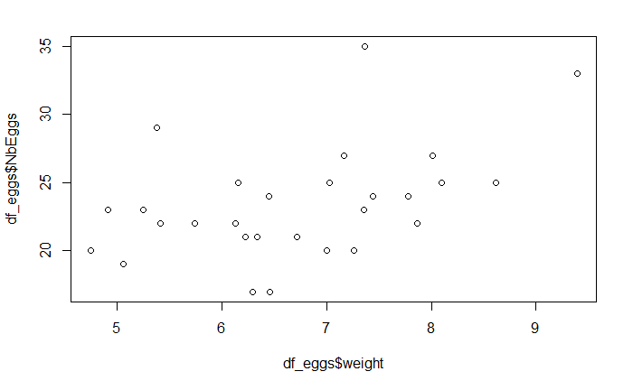

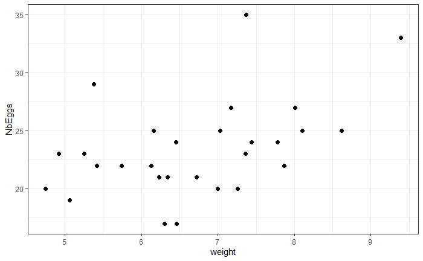

## correlation

- estimate the correlation with `cor.test()`

```r
cor.test(df_eggs$weight,df_eggs$NbEggs)
```

```
    Pearson's product-moment correlation

data:  df_eggs$weight and df_eggs$NbEggs
t = 2.6035, df = 26, p-value = 0.01505
alternative hypothesis: true correlation is not equal to 0
95 percent confidence interval:
 0.09835854 0.70775099
sample estimates:
      cor
0.4547483
```

- do ?cor.test and try to do Pearson and Spearman. Explain the difference

```r
cor.test(df_eggs$weight,df_eggs$NbEggs,method = "spearman",exact = F)
```

```
    Spearman's rank correlation rho

data:  df_eggs$weight and df_eggs$NbEggs
S = 2019.5, p-value = 0.017
alternative hypothesis: true rho is not equal to 0
sample estimates:
      rho
0.4473239
```

## linear regression

- do a linear regression predicting the number of eggs in funciton of the weight using `lm()`

```r
fit <- lm(formula = NbEggs ~ weight,
          data = df_eggs)
```

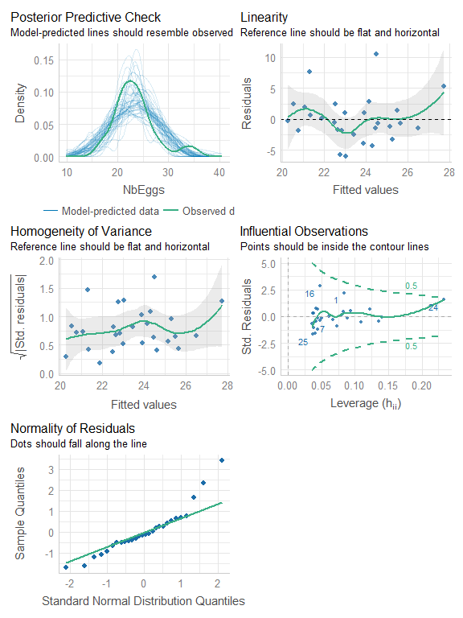

```r
library(performance)
check_model(fit)
```

- inspect the coefficient using `summary()`

```r
summary(fit)
```

```
Call:
lm(formula = NbEggs ~ weight, data = df_eggs)

Residuals:
    Min      1Q  Median      3Q     Max
-6.0367 -1.8018 -0.5588  1.5818 10.5015

Coefficients:
            Estimate Std. Error t value Pr(>|t|)
(Intercept)   12.659      4.196   3.017  0.00565 **
weight         1.606      0.617   2.604  0.01505 *
---
Signif. codes:  0 ‘***’ 0.001 ‘**’ 0.01 ‘*’ 0.05 ‘.’ 0.1 ‘ ’ 1

Residual standard error: 3.733 on 26 degrees of freedom
Multiple R-squared:  0.2068,    Adjusted R-squared:  0.1763
F-statistic: 6.778 on 1 and 26 DF,  p-value: 0.01505
```

$$y = a\times x + b$$

| term | estimate | std.error | statistic | p.value |
| --- | --- | --- | --- | --- |
| (Intercept) | 12.659462 | 4.1960625 | 3.016986 | 0.00564746 |
| weight | 1.606388 | 0.6169998 | 2.603547 | 0.01504597 |

- What do the coefficients mean ?
- could you predict the Number of eggs of a 15 g Platorchestia ?
- Extra: plot the prediction

```r
predict(fit)
```

```
       1        2        3        4        5        6        7        8        9       10       11       12
21.30183 24.48248 22.50662 20.28980 25.67120 26.50653 22.77971 24.61099 24.32184 24.17726 25.15716 22.66726
      13       14       15       16       17       18       19       20       21       22       23       24
21.36608 25.30173 21.09300 24.49854 25.52663 20.56289 23.95237 23.02066 20.78778 23.45439 23.90418 27.74344
      25       26       27       28
23.03673 22.84396 22.55481 21.88013
```

```r
predict(fit,
        newdata = data.frame(weight = c(0:100)))
```

```
        1         2         3         4         5         6         7         8         9        10        11
 12.65946  14.26585  15.87224  17.47863  19.08501  20.69140  22.29779  23.90418  25.51056  27.11695  28.72334
       12        13        14        15        16        17        18        19        20        21        22
 30.32973  31.93612  33.54250  35.14889  36.75528  38.36167  39.96805  41.57444  43.18083  44.78722  46.39361
       23        24        25        26        27        28        29        30        31        32        33
 47.99999  49.60638  51.21277  52.81916  54.42554  56.03193  57.63832  59.24471  60.85110  62.45748  64.06387
       34        35        36        37        38        39        40        41        42        43        44
 65.67026  67.27665  68.88303  70.48942  72.09581  73.70220  75.30859  76.91497  78.52136  80.12775  81.73414
       45        46        47        48        49        50        51        52        53        54        55
 83.34052  84.94691  86.55330  88.15969  89.76608  91.37246  92.97885  94.58524  96.19163  97.79801  99.40440
       56        57        58        59        60        61        62        63        64        65        66
101.01079 102.61718 104.22357 105.82995 107.43634 109.04273 110.64912 112.25550 113.86189 115.46828 117.07467
       67        68        69        70        71        72        73        74        75        76        77
118.68106 120.28744 121.89383 123.50022 125.10661 126.71299 128.31938 129.92577 131.53216 133.13855 134.74493
       78        79        80        81        82        83        84        85        86        87        88
136.35132 137.95771 139.56410 141.17048 142.77687 144.38326 145.98965 147.59604 149.20242 150.80881 152.41520
       89        90        91        92        93        94        95        96        97        98        99
154.02159 155.62797 157.23436 158.84075 160.44714 162.05353 163.65991 165.26630 166.87269 168.47908 170.08546
      100       101
171.69185 173.29824
```

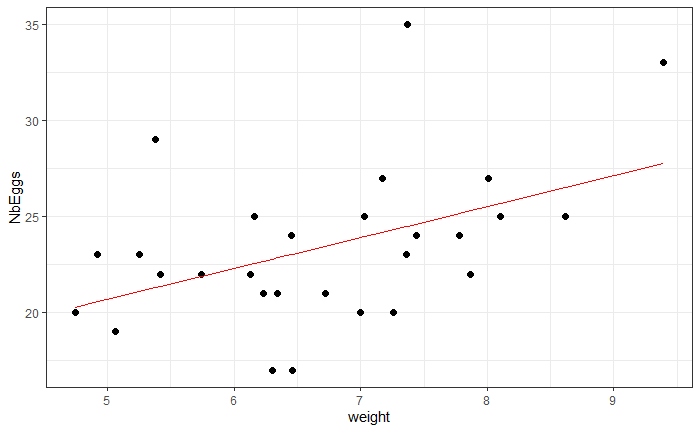

base R:

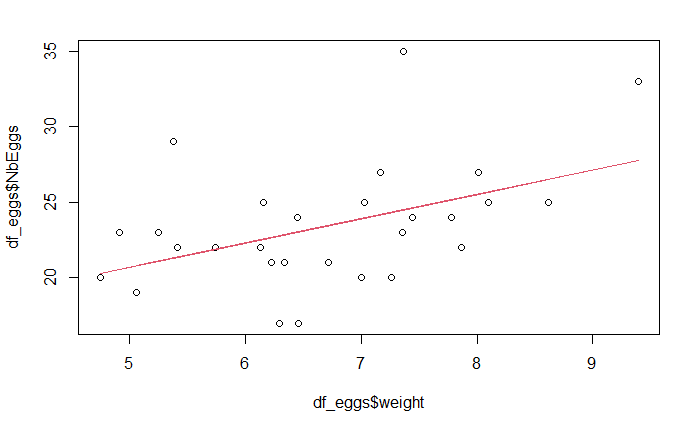

```r
plot(df_eggs$weight,df_eggs$NbEggs)
lines(df_eggs$weight,df_eggs$predict,col = 2)
```

# diet

| Subjectn | Gender | Age | Height | pre.weight | weight6weeks | Weight.Diff |
| --- | --- | --- | --- | --- | --- | --- |
| 1 | 0 | 22 | 159 | 58 | 54.2 | -3.8 |
| 2 | 0 | 46 | 192 | 60 | 54.0 | -6.0 |
| 3 | 0 | 55 | 170 | 64 | 63.3 | -0.7 |
| 4 | 0 | 33 | 171 | 64 | 61.1 | -2.9 |
| 5 | 0 | 50 | 170 | 65 | 62.2 | -2.8 |
| 6 | 0 | 50 | 201 | 66 | 64.0 | -2.0 |
| 7 | 0 | 37 | 174 | 67 | 65.0 | -2.0 |
| 8 | 0 | 28 | 176 | 69 | 60.5 | -8.5 |
| 9 | 0 | 28 | 165 | 70 | 63.1 | -6.9 |
| 10 | 0 | 45 | 165 | 70 | 68.9 | -1.1 |

[output cut: 68 more lines]

## plot

represent the relationship between the weight loss `Weight.Diff` and `Age`, `height`, and `pre.weight`

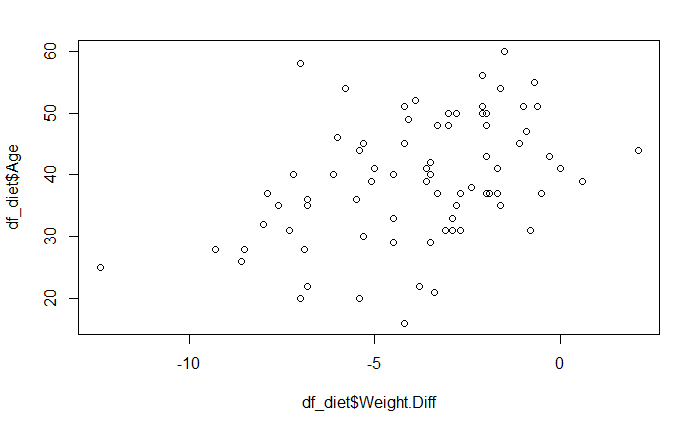

etc. ggplot:

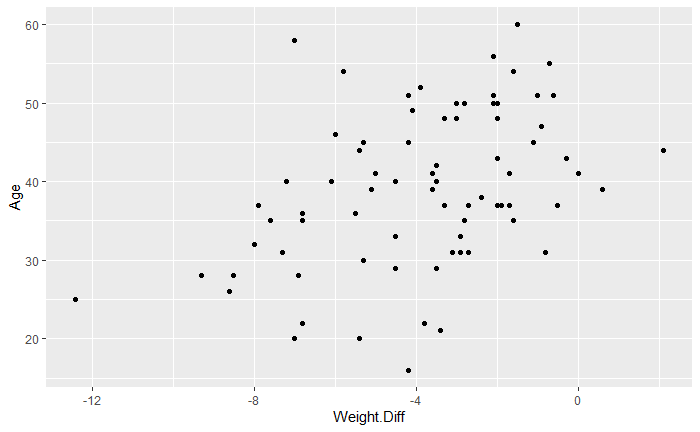

```r
ggplot(df_diet)+
  geom_point(aes(Weight.Diff,Age))
```

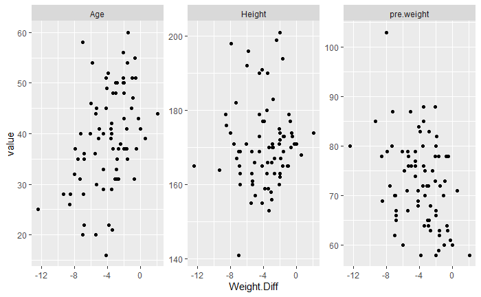

```r
df_diet %>%
  pivot_longer(cols = c("Age", "Height", "pre.weight"),names_to = "variable") %>%
  ggplot(aes(Weight.Diff,value))+
  geom_point()+
  facet_wrap(~variable,scales = "free")
```

```r
NA
```

## correlations

test the correlations between `Weight.Diff` and the other variables

```r
cor.test(df_diet$Weight.Diff,df_diet$Height)
```

```
    Pearson's product-moment correlation

data:  df_diet$Weight.Diff and df_diet$Height
t = 0.47003, df = 76, p-value = 0.6397
alternative hypothesis: true correlation is not equal to 0
95 percent confidence interval:
 -0.1707383  0.2730969
sample estimates:
       cor
0.05383799
```

```r
df_diet$Weight.Diff
```

```
 [1]  -3.8  -6.0  -0.7  -2.9  -2.8  -2.0  -2.0  -8.5  -6.9  -1.1  -1.5  -3.0  -3.6  -1.9   0.6  -3.1  -4.5
[18]  -2.1  -2.0 -12.4  -3.9  -3.5  -5.1  -3.5   0.0  -8.0   2.1  -2.0  -1.7  -0.3  -7.0  -0.6  -2.7  -1.6
[35]  -3.0  -2.0  -4.2  -2.7  -5.3  -4.5  -4.2  -2.4  -5.8  -4.5  -5.3  -1.7  -5.4  -6.1  -7.9  -3.6  -7.3
[52]  -1.0  -1.6  -3.4  -6.8  -6.8  -5.4  -6.8  -4.2  -7.0  -3.3  -2.9  -7.6  -2.1  -3.3  -5.0  -5.5  -0.9
[69]  -3.5  -0.5  -0.8  -8.6  -4.5  -2.8  -4.1  -9.3  -7.2  -2.1
```

```r
cor.test(-df_diet$Weight.Diff,df_diet$pre.weight)
```

```
    Pearson's product-moment correlation

data:  -df_diet$Weight.Diff and df_diet$pre.weight
t = 3.2905, df = 76, p-value = 0.001518
alternative hypothesis: true correlation is not equal to 0
95 percent confidence interval:
 0.1417362 0.5337191
sample estimates:
      cor
0.3531291
```

```r
cor.test(df_diet$Weight.Diff,df_diet$Age)
```

```
    Pearson's product-moment correlation

data:  df_diet$Weight.Diff and df_diet$Age
t = 3.9546, df = 76, p-value = 0.0001706
alternative hypothesis: true correlation is not equal to 0
95 percent confidence interval:
 0.2098736 0.5821267
sample estimates:
      cor
0.4131108
```

## regression

- perform the regression `Weight.Diff` in function of the weight before pre.weight, and interpret the result.

```r
lm(Weight.Diff ~ pre.weight,data = df_diet) %>%
  summary()
```

```
Call:
lm(formula = Weight.Diff ~ pre.weight, data = df_diet)

Residuals:
    Min      1Q  Median      3Q     Max
-7.7573 -1.3703  0.2852  1.7052  4.4320

Coefficients:
            Estimate Std. Error t value Pr(>|t|)
(Intercept)  3.75988    2.33149   1.613  0.11097
pre.weight  -0.10503    0.03192  -3.290  0.00152 **
---
Signif. codes:  0 ‘***’ 0.001 ‘**’ 0.01 ‘*’ 0.05 ‘.’ 0.1 ‘ ’ 1

Residual standard error: 2.443 on 76 degrees of freedom
Multiple R-squared:  0.1247,    Adjusted R-squared:  0.1132
F-statistic: 10.83 on 1 and 76 DF,  p-value: 0.001518
```

```r
lm(Weight.Diff ~ pre.weight + Age + as.factor(Gender),data = df_diet) %>%
  summary()
```

```
Call:
lm(formula = Weight.Diff ~ pre.weight + Age + as.factor(Gender),
    data = df_diet)

Residuals:
    Min      1Q  Median      3Q     Max
-6.3797 -1.7005  0.2765  1.5943  4.3247

Coefficients:
                   Estimate Std. Error t value Pr(>|t|)
(Intercept)         0.60134    3.38754   0.178   0.8596
pre.weight         -0.12370    0.04844  -2.553   0.0128 *
Age                 0.10804    0.02599   4.157 8.78e-05 ***
as.factor(Gender)1  0.57292    0.77387   0.740   0.4615
---
Signif. codes:  0 ‘***’ 0.001 ‘**’ 0.01 ‘*’ 0.05 ‘.’ 0.1 ‘ ’ 1

Residual standard error: 2.229 on 72 degrees of freedom
  (2 observations effacées parce que manquantes)
Multiple R-squared:  0.2647,    Adjusted R-squared:  0.2341
F-statistic: 8.639 on 3 and 72 DF,  p-value: 5.686e-05
```

```r
lm(Weight.Diff ~  Age,data = df_diet) %>%
  summary()
```

```
Call:
lm(formula = Weight.Diff ~ Age, data = df_diet)

Residuals:
    Min      1Q  Median      3Q     Max
-6.9967 -1.4198  0.1732  1.7981  5.4285

Coefficients:
            Estimate Std. Error t value Pr(>|t|)
(Intercept) -8.13345    1.11423  -7.300 2.38e-10 ***
Age          0.10920    0.02761   3.955 0.000171 ***
---
Signif. codes:  0 ‘***’ 0.001 ‘**’ 0.01 ‘*’ 0.05 ‘.’ 0.1 ‘ ’ 1

Residual standard error: 2.378 on 76 degrees of freedom
Multiple R-squared:  0.1707,    Adjusted R-squared:  0.1597
F-statistic: 15.64 on 1 and 76 DF,  p-value: 0.0001706
```

Other tools for regression (among a lot): - `nls()` for non linear regression; - `lmer()` for mixed effect models; - `brms` for bayesian regressions. - {lavaan} for structural equation modeling - {geepack} and `gee` for generalised estimating equations

Machine learning:

- https://keras.rstudio.com/
- https://www.tidymodels.org/
- https://docs.h2o.ai/h2o/latest-stable/h2o-docs/data-science.html#supervised